# Dengue Forecasting Project

## 5.2 Seasonal ARIMA Model

When a model is fit by manual setting of parameters.

I fit an ARIMA(0,1,1)(0,1,1)[12] model.

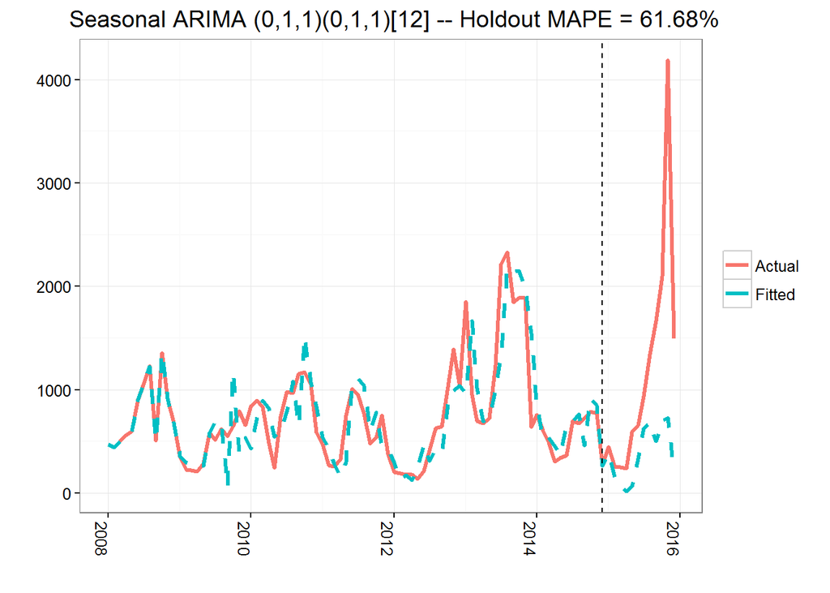

I fit an ARIMA(1,0,3)(1,1,1)[12] model.

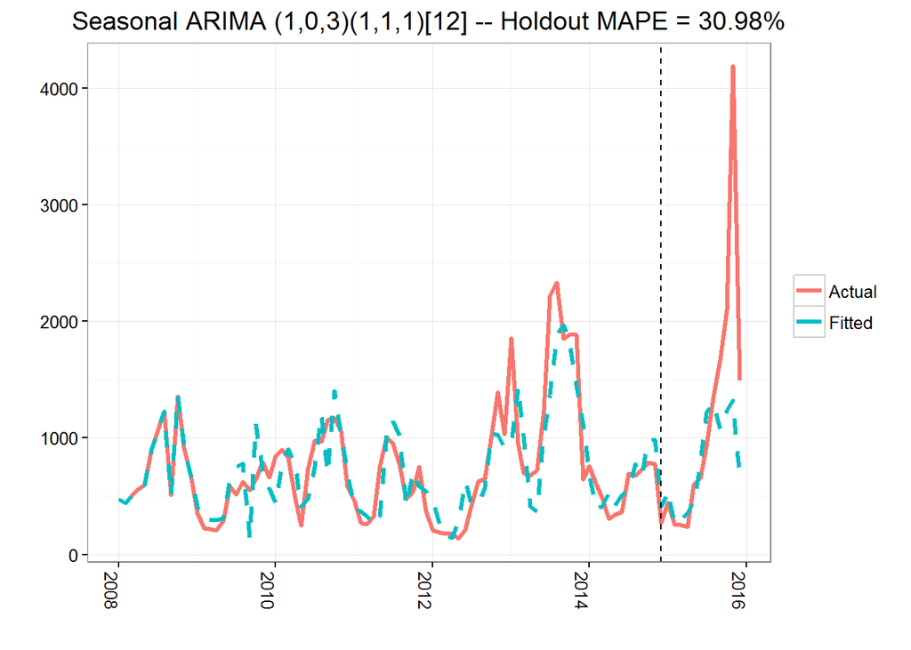

## 5.3 A Bayesian Structural Time Series Model

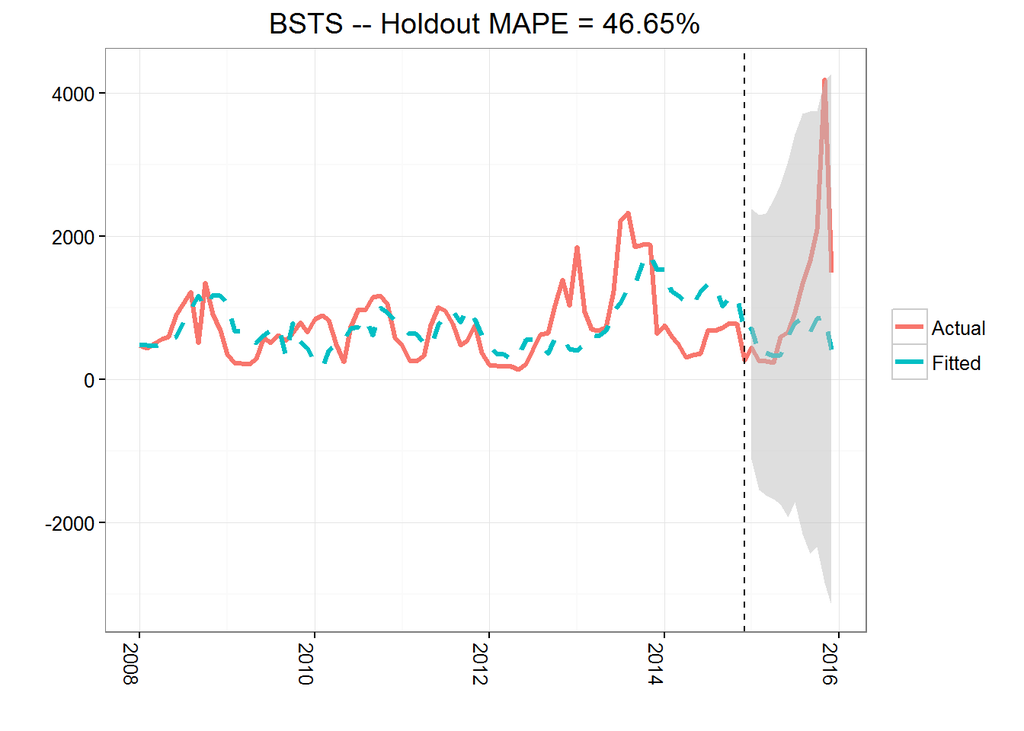

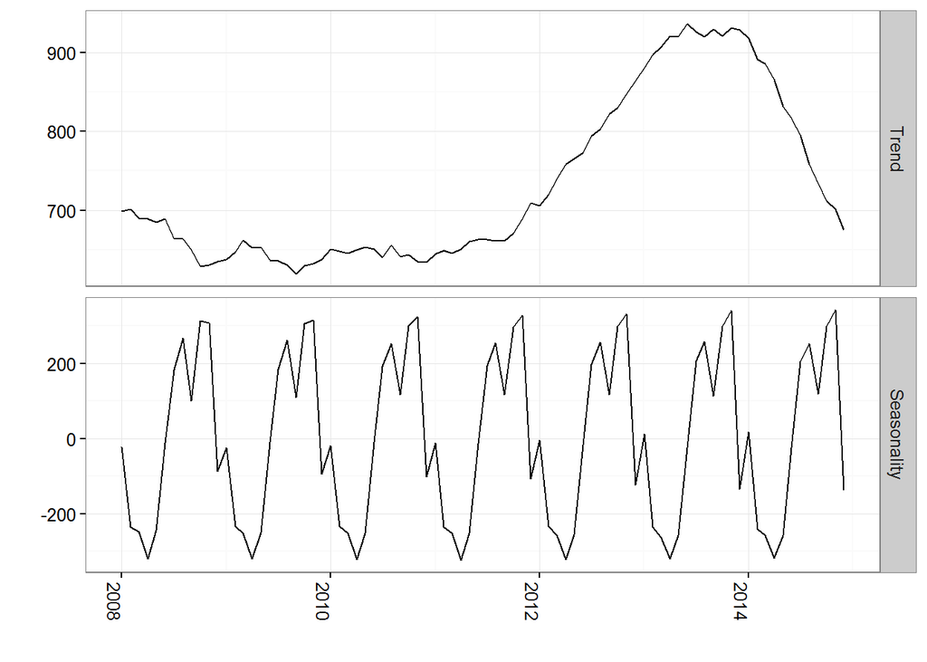

## 5.4 A Structured Bayesian Network Approach

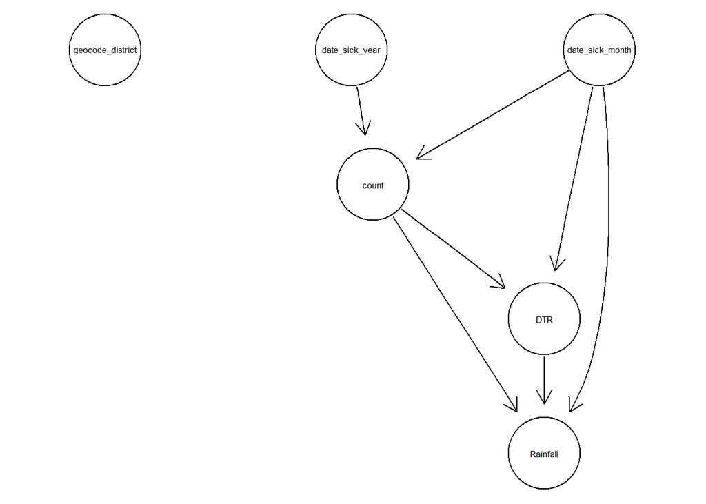

```
                ME    RMSE      MAE       MPE     MAPE
Test set -1.063421 10.0441 6.664085 -60.43833 79.39199
```

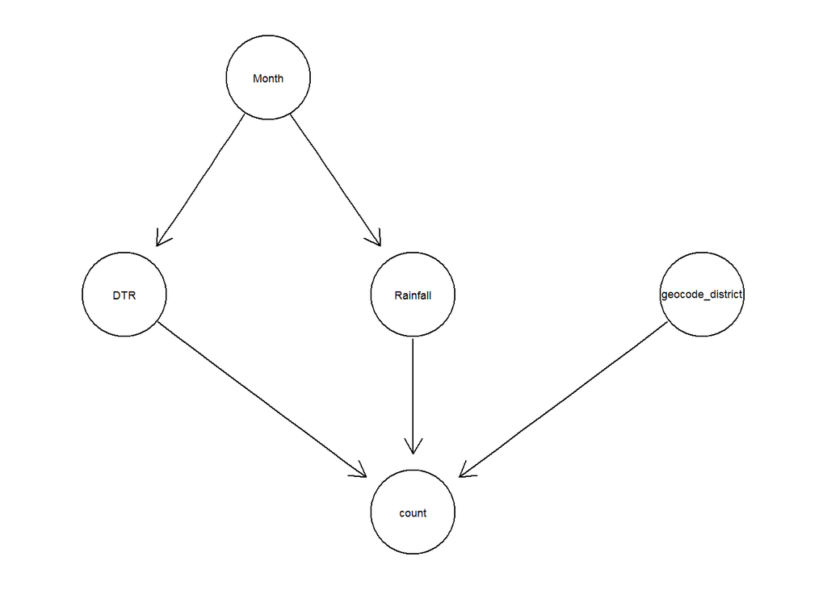

```r
accuracy(f = pred, x =  bayesianDF.test[, "count"])
```

```
               ME     RMSE      MAE      MPE     MAPE
Test set 8.765601 27.51189 16.08321 -87.3934 135.7163
```

## 5.5 Generalized Additive Model

Now, I analyse the dataset according using the Generalized Additive Model.

The dataset consists of following entries:

1. Information of each district
   - identification codes
   - name of the district.
   - population (divided into various age bins)
   - area in square kms.
   - Number of communities
   - number of neighboring districts
2. Monthly DHF count in each district from 2008~2015
3. Monthly average rainfall in Bangkok from 2008~2015
4. Monthly Diurnal Temperature Range (DTR) in Bangkok from 2008~2015

The map of Bangkok is shown below.

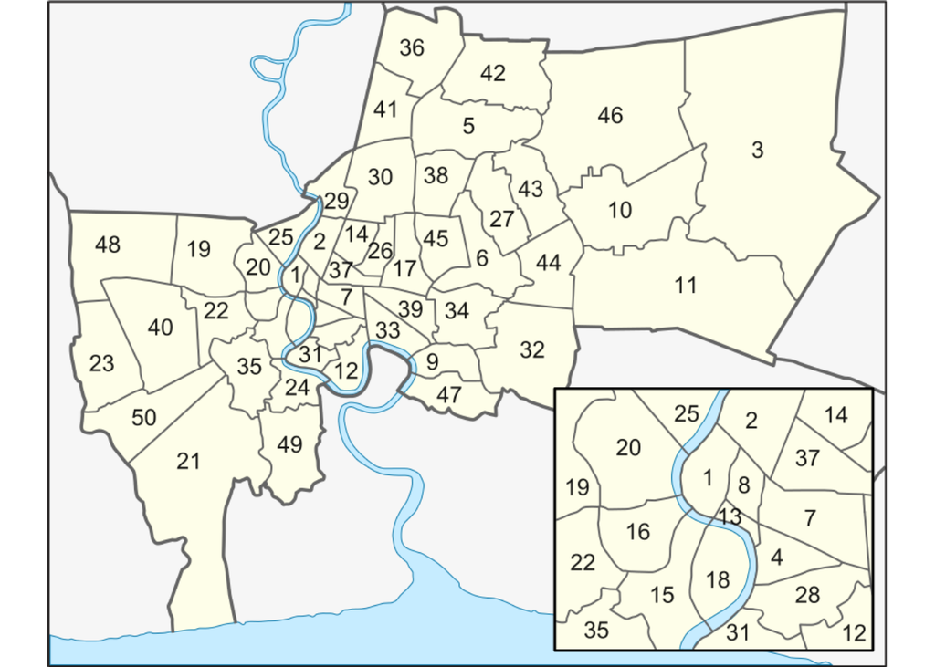

There are 18 districts that are close to stream as shown in the above map. Their names are:

```
 [1] "Bang Su"         "Dusit"           "Bang Plad"
 [4] "Phra Nakhon"     "Bangkok Noi"     "Bangkok Yai"
 [7] "Thon Buri"       "Khlong San"      "Pom Pram Sattru"
[10] "Samphantawong"   "Bang Rak"        "Sathorn"
[13] "Bang Kho Laem"   "Yannawa"         "Rat Burana"
[16] "Khlong Toey"     "Prakanong"       "Bang Na"
```

## 5.6 Study Area 1

For the ease of experimentation, I use the data from first district (indexed as 1 in the image of Bangkok) and perform the our analyses. The name of the district is Phra Nakhon. As you can see, it is located near the stream.

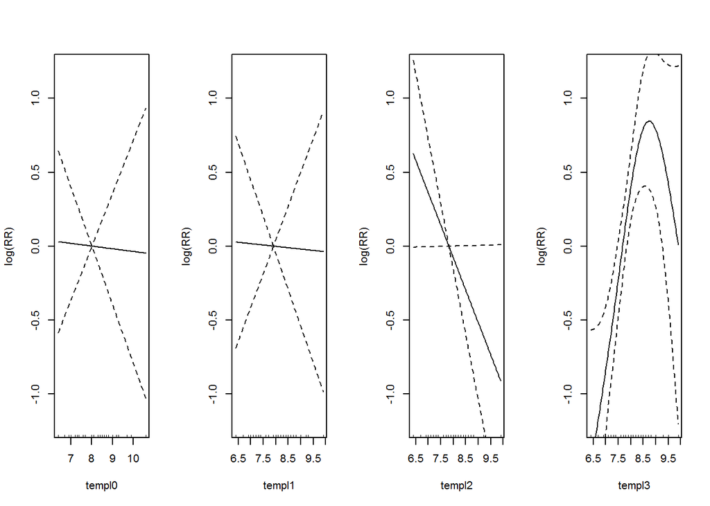

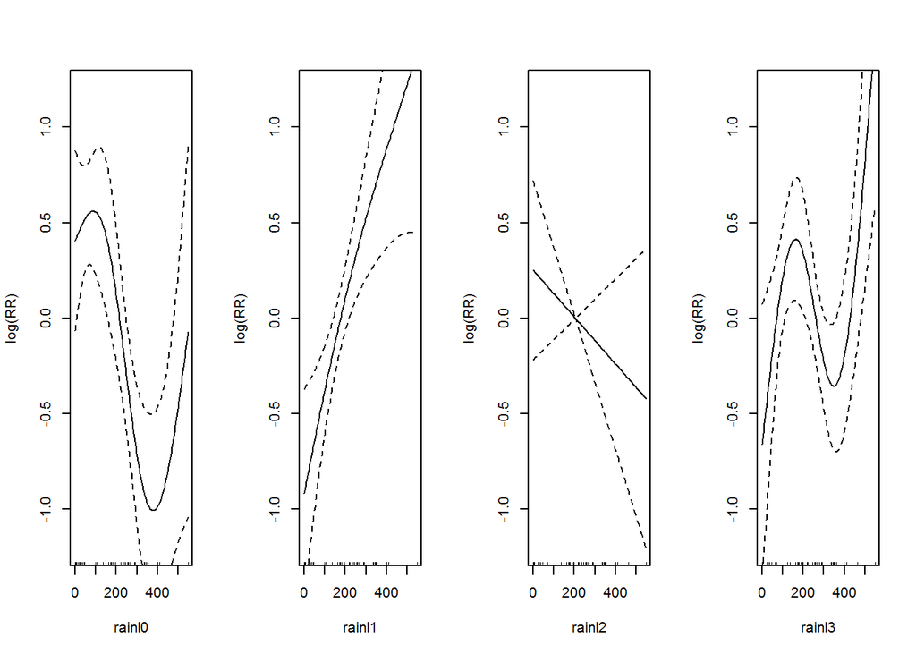

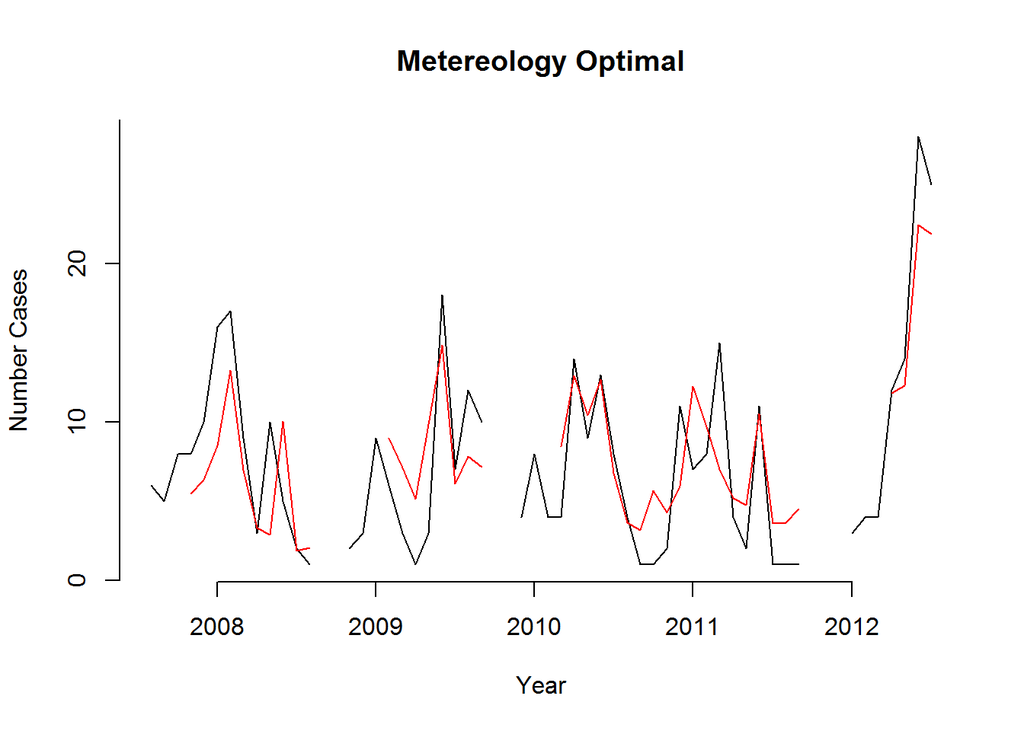

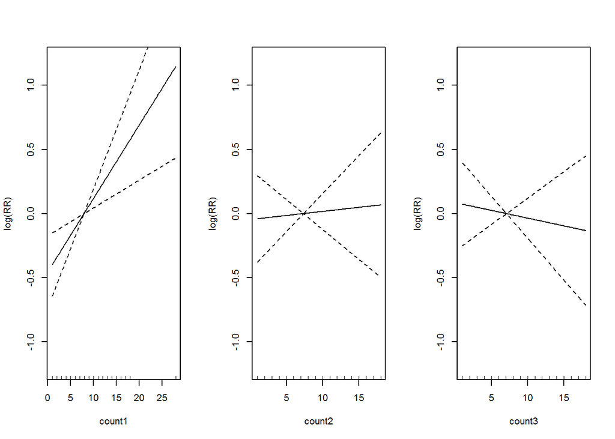

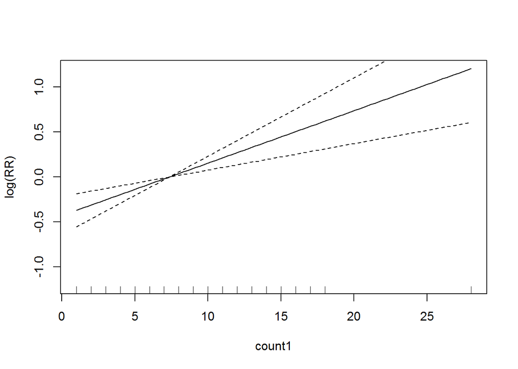

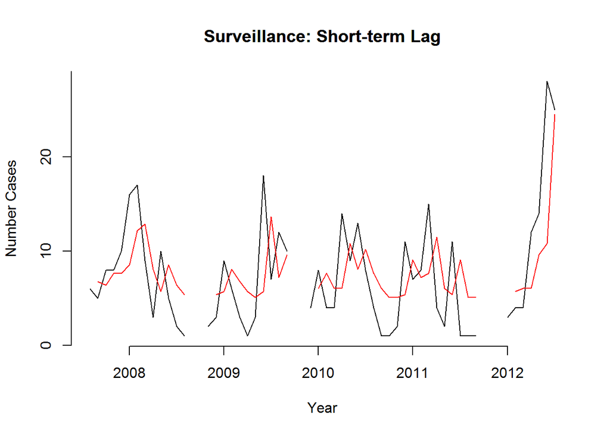

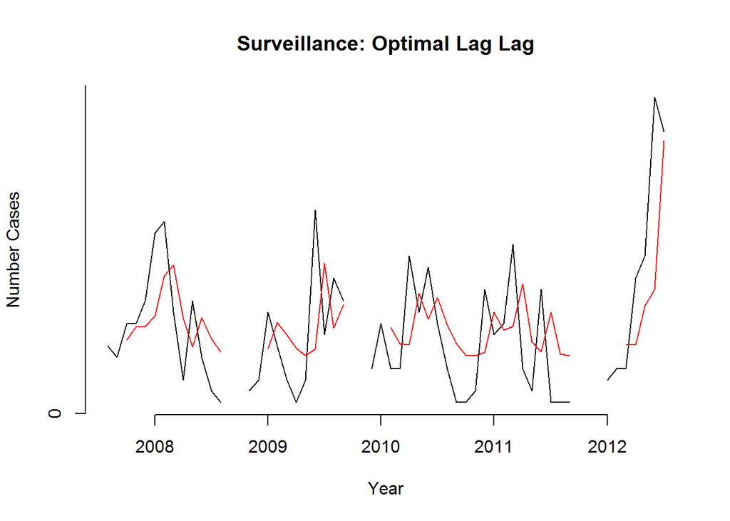

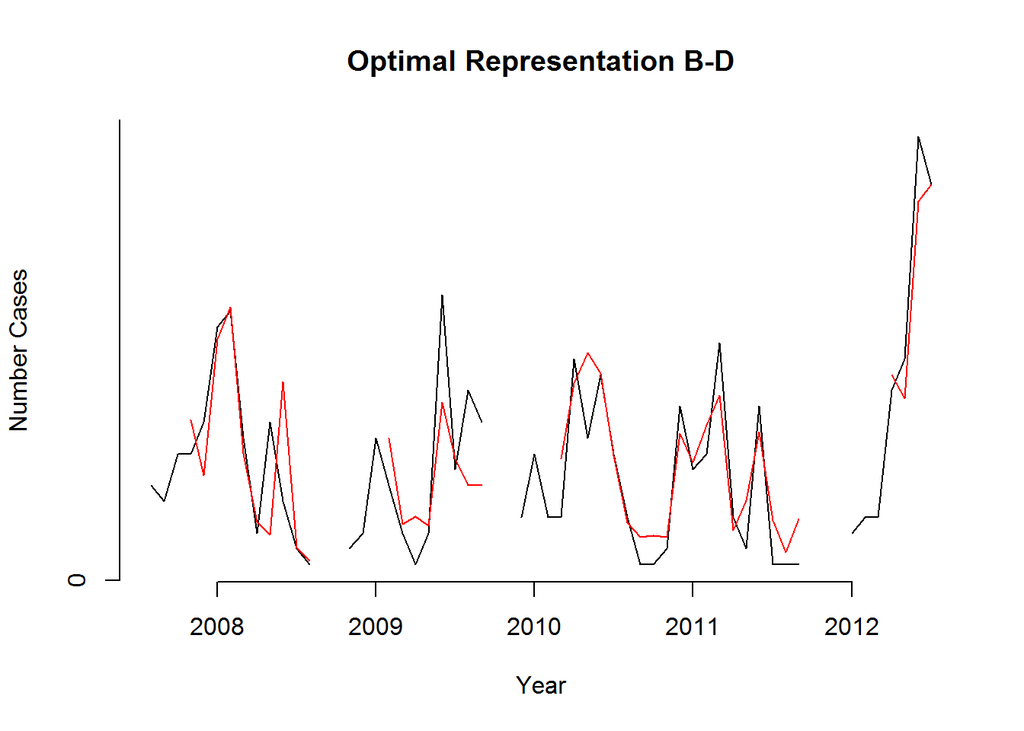

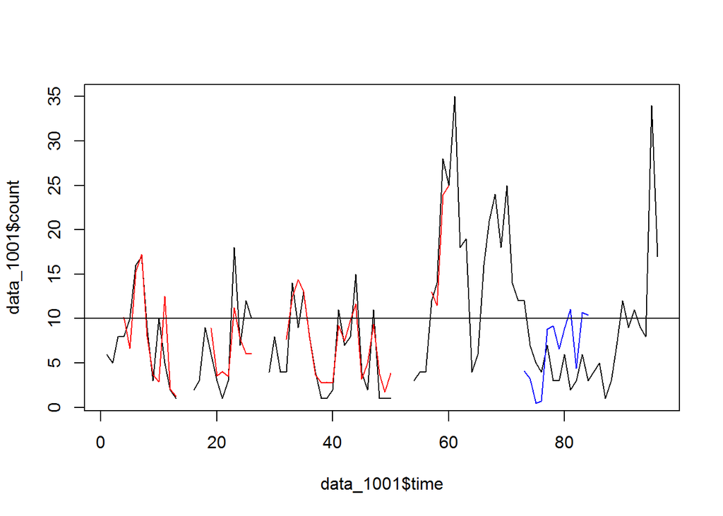

## 5.8 Notes to myself:

- I need to create the lagged values for each district.
- Separate the data into training and testing datasets. Keep the year variable flexible, so that I can experiment with year variables
- Row bind all the training datasets i.e. the data from 50 BKK districts
- Row bind all the data from the testing datasets similar to above.
- make tests.